# Hand-in Homework 3 - Shuhan

Shuhan He

9/24/2020

## 1. Honeybee prediction model

```r
bee <- tibble(ID=1:7,Distance=c(200,250,500,950,1950,3500,4300),Duration=c(0.40,0.45,0.95,1.30,2.00,3.10,4.10))
```

1. There is a strong positive linear relationship between the duration and distance.

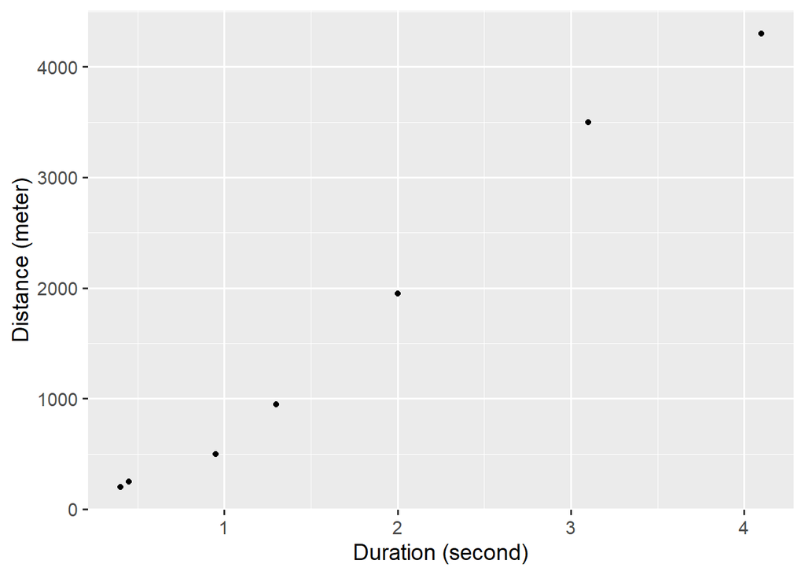

```r
ggplot(bee,aes(x=Duration,y=Distance)) + geom_point()+
  labs(x="Duration (second)",y="Distance (meter)")
```

(b)The correlation is 0.9941942.

```r
m <- lm(Distance~Duration,data=bee)
summary(m)
```

```
##
## Call:
## lm(formula = Distance ~ Duration, data = bee)
##
## Residuals:
##         1         2         3         4         5         6         7
##  129.3496  120.6367 -216.4921 -177.4822    0.5374  258.8541 -115.4035
##
## Coefficients:
##             Estimate Std. Error t value Pr(>|t|)
## (Intercept)  -399.05     124.10  -3.215   0.0236
## Duration     1174.26      56.84  20.661 4.92e-06
##
## Residual standard error: 194.9 on 5 degrees of freedom
## Multiple R-squared:  0.9884, Adjusted R-squared:  0.9861
## F-statistic: 426.9 on 1 and 5 DF,  p-value: 4.918e-06
```

(c)Equation of the least squares line:

Predicted Distance = -399.0526508+ 1174.2576061Duration

(d)residual plot and histogram of the residual

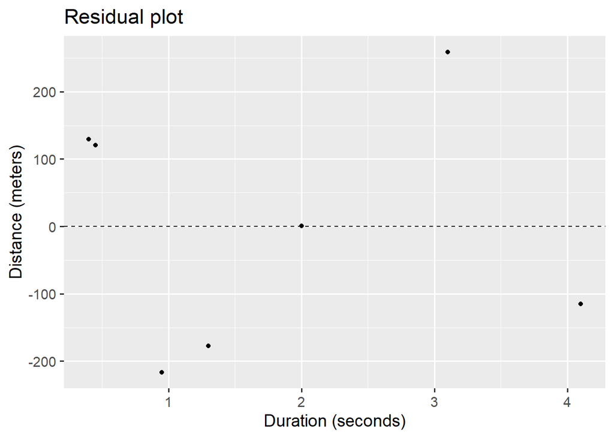

```r
ggplot(bee,aes(x=Duration,y=resid(m))) + geom_point() +
  labs(x="Duration (seconds)",y="Distance (meters)",title="Residual plot") +
  geom_hline(yintercept=0,linetype="dashed")
```

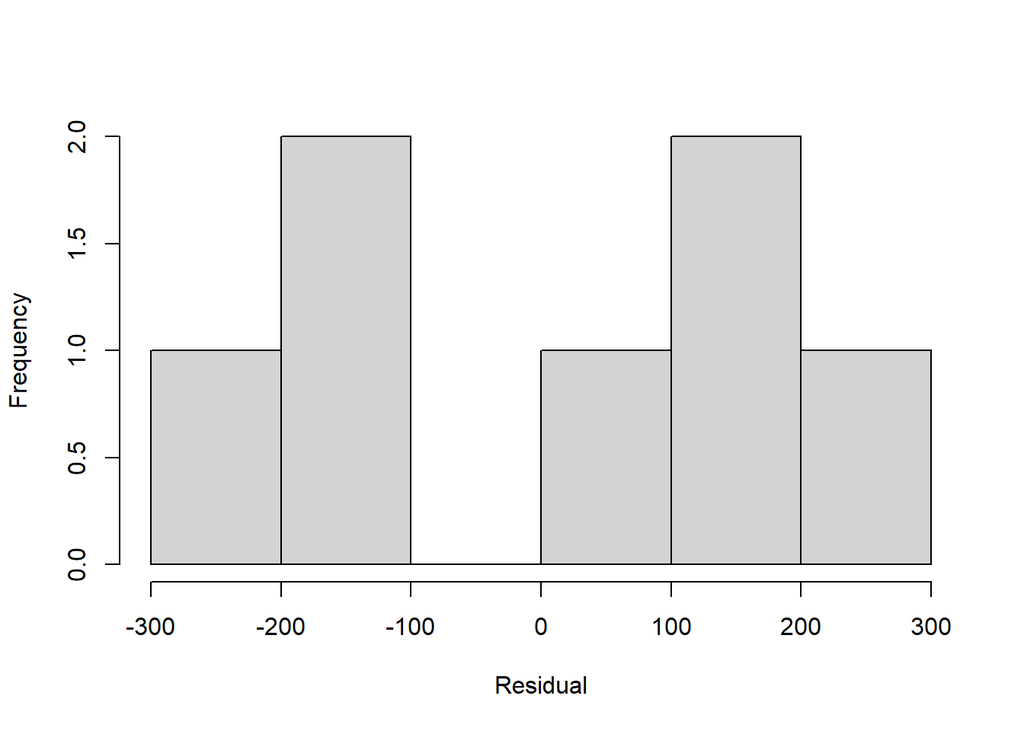

```r
hist(resid(m),xlab="Residual",main="")
```

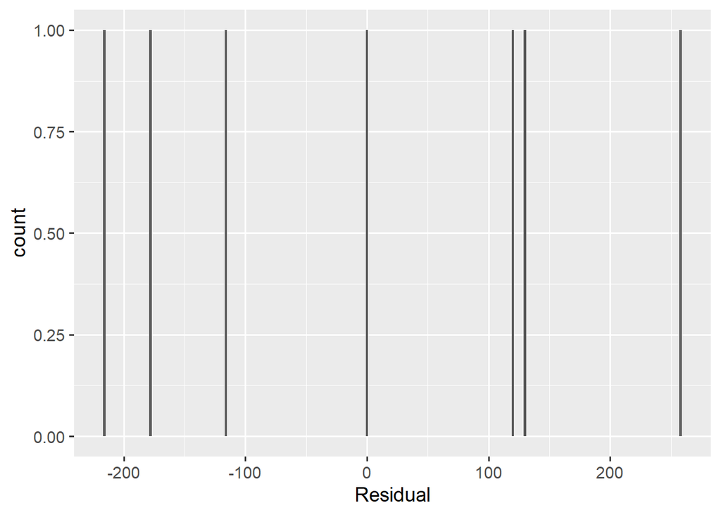

```r
ggplot(NULL,aes(x=resid(m))) + geom_histogram(binwidth=2) + xlab("Residual")
```

(e)According to the least squares line, predicted Distance increases by 1174 meter for every additional 1 second in Duration.

(f)The value of R sqare is 0.9884221which indicates 98.8% of the variation in distance to the food source is explained by bee dance’s duration. The value of standard deviation of the residuals is $s_e$ 194.9240875which tells that we expect the predictions from this model to be off about 194.9240875meters on average from the same duration.

(g)The predicted distance to the food sourse if a honeybee does a waggle dance lasting 1 second is 775.2049554. The predicted distance to the food sourceif a honeybee does a waggle dance lasting 3 second is 3123.7201676.

## 2 Cranes question

(a)Plot of Count vs. Year

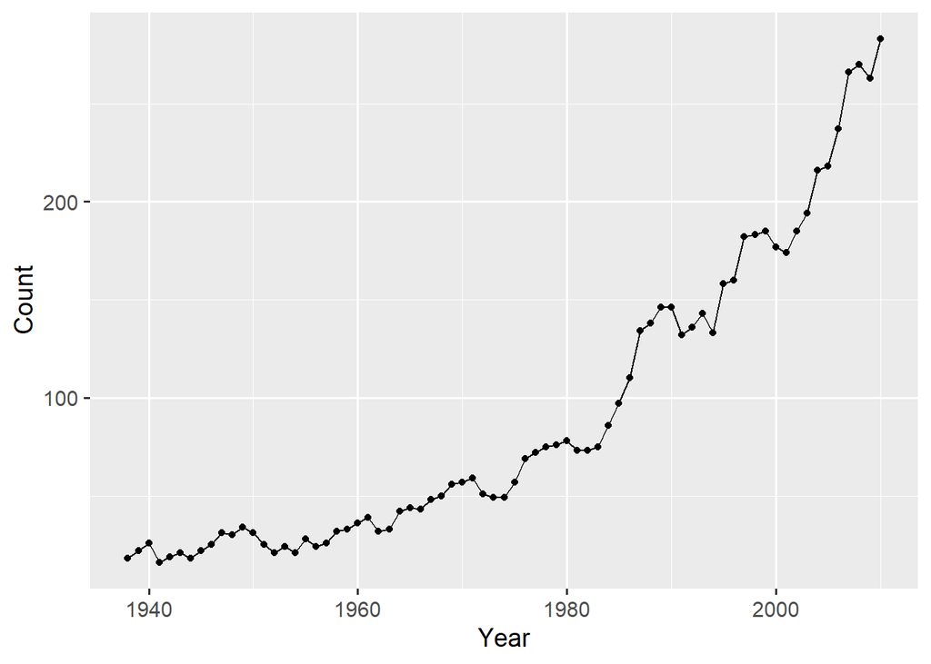

```r
p<-read_csv("Cranes.csv")
ggplot(p,aes(x=Year,y=Count)) + geom_point() + geom_line()
```

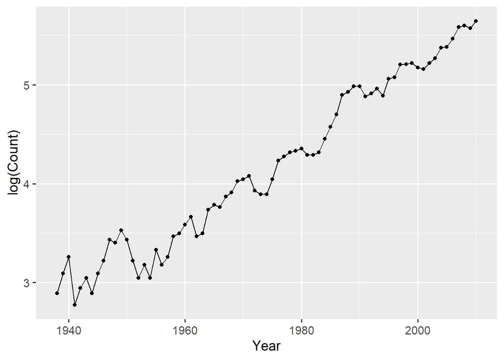

```r
ggplot(p,aes(x=Year,y=log(Count))) + geom_point() + geom_line()
```

```r
v <- lm(log10(Count)~Year,data=p)
summary(v)
```

```
##
## Call:
## lm(formula = log10(Count) ~ Year, data = p)
##
## Residuals:
##       Min        1Q    Median        3Q       Max
## -0.146236 -0.038362 -0.003625  0.030523  0.185433
##
## Coefficients:
##               Estimate Std. Error t value Pr(>|t|)
## (Intercept) -3.188e+01  7.466e-01  -42.69   <2e-16
## Year         1.707e-02  3.782e-04   45.12   <2e-16
##
## Residual standard error: 0.06809 on 71 degrees of freedom
## Multiple R-squared:  0.9663, Adjusted R-squared:  0.9658
## F-statistic:  2036 on 1 and 71 DF,  p-value: < 2.2e-16
```

(d)The predicted log(Count) at year 2020 is 2.594767, so the predicted number of whooping cranes at year 2020 is 393. The predicted log(Count) at year 2050 is 3.1067269, so the predicted number of whooping cranes at year 2050 is 1279.